# Linguistic Predictors of Concreteness

anonymous

3/26/2019

## Introduction

This script analyzes several linguistic predictors of concreteness and abstractness:

- part-of-speech
- number of morphemes
- count/mass distinction
- etymology

First, each linguistic factor will be analyzed separately; then they will be analyzed in a simultaneous regression analysis.

Load in the data:

```r
library(tidyverse)
library(car) # for variance inflation factors vif()
library(broom) # for glance()
library(rsq)
library(gridExtra)
library(textstem) # for lemmatize_strings()
library(effsize)

# Brysbaert concreteness ratings:

conc <- read_csv('../data/brysbaert_concreteness.csv')

# SUBTLEX POS Tags:

SUBTL <- read_csv('../data/SUBTLEX_US_with_POS.csv')

# ELP POS tags & ELP number of morphemes:

ELP <- read_csv('../data/ELP_with_POS_cleaned.csv')

# BECL countability data:

BECL <- read_csv('../data/BECL.csv')

# Etymologies:

etym <- read_csv('../data/monaghan_roberts_etymologies.csv')

# Load in morpholex data:

morph <- read_csv('../data/morpholex_one_derivational_suffix.csv')
nosuffix <- read_csv('../data/morpholex_no_suffix.csv')

# Timo's beautiful ggplot2 theme:

source('theme_timo.R')
```

## Preprocessing:

Lemmatize all strings (get rid of inflectional morphology), except for -est, which we treat as derivational here given that’s how it is treated in MorphoLex (see paper for discussion of -est).

```r
conc$Lemmas <- conc$Word
ids <- !str_detect(conc$Word, 'est')
conc[ids, ]$Lemmas <- lemmatize_strings(conc[ids, ]$Word)

# Get rid of 'duplicates'

conc <- filter(conc,
               !duplicated(Lemmas))

# Replace "Word" column with "lemma" column:

conc <- mutate(conc,
               Word = Lemmas)
```

Merge SUBTLEX POS and ELP data into conc:

```r
# SUBTLEX parts-of-speech tags:
conc$SUBTL_POS <- SUBTL[match(conc$Word, SUBTL$Word), ]$Dom_PoS_SUBTLEX
conc$SUBTL_percent <- SUBTL[match(conc$Word, SUBTL$Word), ]$Percentage_dom_PoS
conc$SUBTL_allPOS <- SUBTL[match(conc$Word, SUBTL$Word), ]$All_PoS_SUBTLEX

# ELP parts-of-speech tags:

conc$ELP_POS <- ELP[match(conc$Word, ELP$Word), ]$POS

# Number of letters from ELP:

conc$Letters <- ELP[match(conc$Word, ELP$Word), ]$Length

# Number of phonemes:

conc$NPhon <- ELP[match(conc$Word, ELP$Word), ]$NPhon

# Number of morphemes:

conc$NMorph <- ELP[match(conc$Word, ELP$Word), ]$NMorph

# Number of morphemes:

conc$NMorph <- ELP[match(conc$Word, ELP$Word), ]$NMorph
```

Process etymologies… first clean the strings:

```r
etym <- filter(etym, word != '#NAME?')
etym <- mutate(etym,
               word = str_replace(word, '\\(.+\\)', ''),
               word = str_trim(word),
               word = str_to_lower(word))
```

Next, sort the labels:

```r
etym$Last <- str_split(etym$links, '%', simplify = TRUE)[, 1]
```

Match this into the concreteness file:

```r
conc$Etym <- etym[match(conc$Word, etym$word), ]$Last

conc_counts <- conc %>% count(Etym, sort = TRUE) %>%
  mutate(large = ifelse(n > 100, 'large', 'small')) %>%
  filter(!is.na(Etym))

conc$EtymSize <- conc_counts[match(conc$Etym, conc_counts$Etym), ]$large
```

Merge the following categories:

- Proto-Germanic / Old English / Middle English = English/Germanic
- Late Latin / Latin / Medieval Latin = Latin
- Middle French / Old French / French / Anglo-French = French

```r
french <- c('Anglo-French', 'French', 'Middle French', 'Old French')
latin <- c('Late Latin', 'Latin', 'Medieval Latin', 'Modern Latin')
english <- c('Middle English', 'Old English', 'Proto-Germanic')
other <- c('Greek', 'Italian', 'Old Norse')
conc$EtymSimplified <- NA
conc <- mutate(conc,
               EtymSimplified = ifelse(Etym %in% french, 'French', EtymSimplified),
               EtymSimplified = ifelse(Etym %in% latin,
                                       'Latin', EtymSimplified),
               EtymSimplified = ifelse(Etym %in% english,
                                       'English', EtymSimplified),
               EtymSimplified = ifelse(Etym %in% other, 'Other', EtymSimplified))
```

In a further step — we will merge “Other” and “English”, as the hypothesis is about French-based versus the rest.

```r
conc <- mutate(conc,
               EtymSimplified = ifelse(EtymSimplified == 'English',
                                       'Other', EtymSimplified))
```

Create a new ‘function word’ category. Comment out ‘pronoun’ category if this is supposed to be excluded from function words.

```r
function_words <- c('Conjunction', 'Determiner',
                    'Preposition', 'Article',
                    'Pronoun',
                    'Ex', 'To', 'Not')
conc <- mutate(conc,
               SUBTL_POS = ifelse(SUBTL_POS %in% function_words,
                                   'Function', SUBTL_POS))
rm(function_words)
```

Set everything else NA:

```r
conc <- mutate(conc,
               SUBTL_POS = ifelse(SUBTL_POS == '#N/A', NA, SUBTL_POS),
               SUBTL_POS = ifelse(SUBTL_POS == 'Interjection', NA, SUBTL_POS),
               SUBTL_POS = ifelse(SUBTL_POS == 'Letter', NA, SUBTL_POS),
               SUBTL_POS = ifelse(SUBTL_POS == 'Name', NA, SUBTL_POS),
               SUBTL_POS = ifelse(SUBTL_POS == 'Number', NA, SUBTL_POS),
               SUBTL_POS = ifelse(SUBTL_POS == 'Unclassified', NA, SUBTL_POS))
```

Add morpheme parses (suffix info):

```r
conc$MorphParse <- morph[match(conc$Word, morph$Word), ]$MorphoLexSegm
```

Create a table of the morphemes:

```r
these_morphs <- c('>ly', '>y', '>er', '>ion', '>al', '>ness', '>ic',
                  '>ate', '>able', '>est', '>ious', '>ity', '>ive',
                  '>ant', '>ist', '>ize', '>less', '>ory', '>ory',
                  '>ful', '>ance')
suffixes <- c('-ly', '-y', '-er', '-ion', '-al', '-ness', '-ic',
              '-ate', '-able', '-est', '-ious', '-ity', '-ive',
              '-ant', '-ist', '-ize', '-less', '-ory', '-ory',
              '-ful', '-ance')
```

Attach these to the concreteness dataset:

```r
conc$Suffix <- NA
conc$Suffix <- as.character(conc$Suffix)

for (i in 1:length(these_morphs)) {
  this_morph <- these_morphs[i]
  conc[which(str_detect(conc$MorphParse, this_morph)), ]$Suffix <- suffixes[i]
}
```

Check:

```r
table(conc$Suffix)
```

```
##
## -able   -al -ance  -ant  -ate   -er  -est  -ful   -ic  -ion -ious  -ist  -ity
##   220   234   114   132   142   656     6   122   155   381   130    99   188
##  -ive  -ize -less   -ly -ness  -ory    -y
##   115    97   182   764   377   137   537
```

Check words that have these suffixes versus words that do not.

```r
conc <- mutate(conc,
               HasSuffix = ifelse(!is.na(Suffix), 'has suffix', 'no suffix'))
```

Since the ‘suffix’ parse is only for bimorphemic words, the ‘no suffix’ category needs to be set to NA for NMorph > 2.

```r
conc[which(conc$NMorph > 2), ]$HasSuffix <- NA
```

Create a “Suffix” column that also includes the no suffixes for plotting purposes:

```r
conc <- mutate(conc,
               SuffixWithMono = ifelse(is.na(Suffix), 'monomorphemic', Suffix))
conc[which(conc$NMorph > 1 & is.na(conc$Suffix)), ]$SuffixWithMono <- NA
conc[which(is.na(conc$NMorph) & is.na(conc$Suffix)), ]$SuffixWithMono <- NA
```

Are standard deviations influenced by word knowledge?

```r
summary(lm(Conc.SD ~ Percent_known, data = conc))
```

```
##
## Call:
## lm(formula = Conc.SD ~ Percent_known, data = conc)
##
## Residuals:
##      Min       1Q   Median       3Q      Max
## -1.24023 -0.16164  0.06261  0.22511  0.74644
##
## Coefficients:
##               Estimate Std. Error t value Pr(>|t|)
## (Intercept)    2.07155    0.03496   59.25   <2e-16 ***
## Percent_known -0.96666    0.03622  -26.68   <2e-16 ***
## ---
## Signif. codes:  0 '***' 0.001 '**' 0.01 '*' 0.05 '.' 0.1 ' ' 1
##
## Residual standard error: 0.3134 on 35966 degrees of freedom
## Multiple R-squared:  0.01942,    Adjusted R-squared:  0.01939
## F-statistic: 712.1 on 1 and 35966 DF,  p-value: < 2.2e-16
```

Yes, but not massively so.

Exclude words that were known by less than 95% of all people in the concreteness rating study. This makes sense because these data are probably noisy:

```r
# How much:

sum(conc$Percent_known < 0.95) / nrow(conc)
```

```
## [1] 0.2854204
```

```r
sum(conc$Percent_known < 0.95)
```

```
## [1] 10266
```

```r
# Exclude:

conc <- filter(conc, Percent_known > 0.95)
```

Get all compounds:

```r
juhasz <- read_csv('../data/juhasz_lai_woodcock_2015.csv')
LADEC <- read_csv('../data/LADECv1-2019.csv')
kim <- read_csv('../data/kim_yap_goh_2019.csv')
```

Get all compound words into one big list:

```r
compounds <- c(juhasz$Compound, LADEC$stim, kim$CW)
compounds <- unique(compounds)
```

Add a “is compound” variable to the conc data frame:

```r
conc <- mutate(conc,
               IsCompound = ifelse(Word %in% compounds,
                                   'Compound', 'No compound'))
```

Crete a subset with low SD items. Here I use an 50th percentile cut-off (median split), so the words with the 50% lowest SD. Other values would make sense too (feel free to change them) and don’t affect the results vastly:

```r
conc_sub <- filter(conc,
                   Conc.SD < quantile(Conc.SD, 0.5))
nrow(conc_sub)
```

```
## [1] 12608
```

```r
nrow(conc) - nrow(conc_sub)
```

```
## [1] 13081
```

```r
1 - (nrow(conc_sub) / nrow(conc))
```

```
## [1] 0.5092063
```

The analyses will be done with both datasets (all SDs allowed and low SD).

## Linguistic factor 1: Part of speech:

Only look at nouns, verbs and adjectives, SUBTLEX:

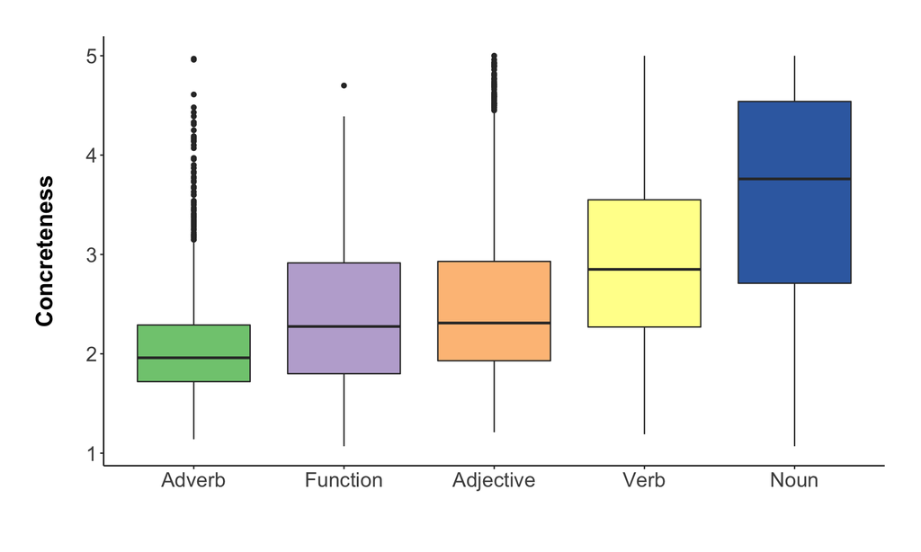

```r
POS <- c('Verb', 'Adjective', 'Noun', 'Adverb', 'Function')
conc_red <- filter(conc,
                   SUBTL_POS %in% POS)

# Plot and aesthetics:

conc_POS <- conc_red %>%
  mutate(SUBTL_POS = factor(SUBTL_POS,
                            levels = c('Adverb', 'Function', 'Adjective',
                                       'Verb', 'Noun'))) %>%
  ggplot(aes(x = SUBTL_POS, y = Conc.M, fill = SUBTL_POS))

# Geoms:

conc_POS <- conc_POS + geom_boxplot()

# Themes and other properties:

conc_POS <- conc_POS +
  labs(x = '', y = 'Concreteness\n') +
  theme_timo +
  theme(legend.position = 'none') +
  scale_fill_brewer(palette = 'Accent')

# Look and save:

conc_POS
```

```r
ggsave(plot = conc_POS, filename = '../figures/POS.pdf',
       width = 8, height = 4.5)
```

Get the descriptive values for reporting:

```r
conc_red %>% group_by(SUBTL_POS) %>%
  summarize(M = mean(Conc.M),
            SD = sd(Conc.M),
            SD = round(SD, 2),
            N = n()) %>%
  arrange(desc(M))
```

```
## # A tibble: 5 x 4
##   SUBTL_POS     M    SD     N
##   <chr>     <dbl> <dbl> <int>
## 1 Noun       3.59  1.03 10855
## 2 Verb       2.95  0.81  2477
## 3 Adjective  2.49  0.73  4175
## 4 Function   2.38  0.77   150
## 5 Adverb     2.08  0.55  1471
```

Nouns are a whopping 1 concreteness pint above adjectives, and about half a point above verbs.

Make a model of this:

```r
xmdl <- lm(Conc.M ~ SUBTL_POS, conc_red)
anova(xmdl)
```

```
## Analysis of Variance Table
##
## Response: Conc.M
##              Df  Sum Sq Mean Sq F value    Pr(>F)
## SUBTL_POS     4  5732.5 1433.12    1722 < 2.2e-16 ***
## Residuals 19123 15914.8    0.83
## ---
## Signif. codes:  0 '***' 0.001 '**' 0.01 '*' 0.05 '.' 0.1 ' ' 1
```

```r
summary(xmdl)$r.squared
```

```
## [1] 0.2648124
```

Repeat for low SD words:

```r
conc_red <- filter(conc_sub,
                   SUBTL_POS %in% POS)
xmdl <- lm(Conc.M ~ SUBTL_POS, conc_red)
anova(xmdl)
```

```
## Analysis of Variance Table
##
## Response: Conc.M
##             Df Sum Sq Mean Sq F value    Pr(>F)
## SUBTL_POS    4 6870.0 1717.50  1612.4 < 2.2e-16 ***
## Residuals 9110 9704.1    1.07
## ---
## Signif. codes:  0 '***' 0.001 '**' 0.01 '*' 0.05 '.' 0.1 ' ' 1
```

```r
summary(xmdl)$r.squared
```

```
## [1] 0.4145024
```

Also significant, explains 41% of the variance.

Get the descriptive values for low SD words:

```r
conc_red %>% group_by(SUBTL_POS) %>%
  summarize(M = mean(Conc.M),
            SD = sd(Conc.M),
            N = n())
```

```
## # A tibble: 5 x 4
##   SUBTL_POS     M    SD     N
##   <chr>     <dbl> <dbl> <int>
## 1 Adjective  2.19 0.824  1682
## 2 Adverb     1.86 0.465   878
## 3 Function   1.78 0.694    50
## 4 Noun       4.00 1.13   5651
## 5 Verb       2.98 1.13    854
```

Basically the same pattern as before, but even more pronounced.

## Linguistic factor 2: Number of morphemes:

Descriptive averages:

```r
conc %>% group_by(IsCompound) %>%
  summarize(M = mean(Conc.M),
            SD = sd(Conc.M),
            SD = round(SD, 2))
```

```
## # A tibble: 2 x 3
##   IsCompound      M    SD
##   <chr>       <dbl> <dbl>
## 1 Compound     3.96  0.92
## 2 No compound  3.06  1.07
```

Assess concreteness difference between compounds and non-compounds:

```r
with(conc, t.test(Conc.M ~ IsCompound, var.equal = TRUE))
```

```
##
##  Two Sample t-test
##
## data:  Conc.M by IsCompound
## t = 41.932, df = 25687, p-value < 2.2e-16
## alternative hypothesis: true difference in means is not equal to 0
## 95 percent confidence interval:
##  0.8556858 0.9396052
## sample estimates:
##    mean in group Compound mean in group No compound
##                  3.959811                  3.062165
```

```r
with(conc, cohen.d(Conc.M ~ IsCompound, var.equal = TRUE))
```

```
##
## Cohen's d
##
## d estimate: 0.854165 (large)
## 95 percent confidence interval:
##     lower     upper
## 0.8135604 0.8947697
```

Compare this against monomorphemics:

```r
conc_comp <- filter(conc,
                    !(IsCompound == 'No compound' & NMorph > 1))
```

Assess concreteness difference between compounds and non-compounds, for monomorphemics as comparison class:

```r
# Descriptive stats:

conc_comp %>% group_by(IsCompound) %>%
  summarize(M = mean(Conc.M),
            SD = sd(Conc.M),
            SD = round(SD, 2))
```

```
## # A tibble: 2 x 3
##   IsCompound      M    SD
##   <chr>       <dbl> <dbl>
## 1 Compound     3.96  0.92
## 2 No compound  3.63  1.02
```

```r
# Inferential stats:

with(conc_comp, t.test(Conc.M ~ IsCompound, var.equal = TRUE))
```

```
##
##  Two Sample t-test
##
## data:  Conc.M by IsCompound
## t = 14.515, df = 8387, p-value < 2.2e-16
## alternative hypothesis: true difference in means is not equal to 0
## 95 percent confidence interval:
##  0.2895584 0.3799767
## sample estimates:
##    mean in group Compound mean in group No compound
##                  3.959811                  3.625043
```

```r
with(conc_comp, cohen.d(Conc.M ~ IsCompound, var.equal = TRUE))
```

```
##
## Cohen's d
##
## d estimate: 0.3394865 (small)
## 95 percent confidence interval:
##     lower     upper
## 0.2933532 0.3856199
```

There are two ways of looking at morphological complexity. One is to look at specific suffixes (Table 1 in the paper).

Get those from the database:

```r
conc_morph <- filter(conc,
                     IsCompound != 'Compound',
                     NMorph <= 2)
```

What about the suffix versus no suffix variable?

```r
conc_morph %>%
  group_by(HasSuffix) %>%
  summarize(M = mean(Conc.M),
            SD = sd(Conc.M),
            SD = round(SD, 2))
```

```
## # A tibble: 2 x 3
##   HasSuffix      M    SD
##   <chr>      <dbl> <dbl>
## 1 has suffix  2.77  0.89
## 2 no suffix   3.44  1.03
```

```r
with(conc_morph, t.test(Conc.M ~ HasSuffix, var.equal = TRUE))
```

```
##
##  Two Sample t-test
##
## data:  Conc.M by HasSuffix
## t = -32.835, df = 11164, p-value < 2.2e-16
## alternative hypothesis: true difference in means is not equal to 0
## 95 percent confidence interval:
##  -0.7167125 -0.6359609
## sample estimates:
## mean in group has suffix  mean in group no suffix
##                 2.765575                 3.441912
```

```r
with(conc_morph, cohen.d(Conc.M ~ HasSuffix, var.equal = TRUE))
```

```
##
## Cohen's d
##
## d estimate: -0.6807682 (medium)
## 95 percent confidence interval:
##      lower      upper
## -0.7223780 -0.6391584
```

```r
with(conc_morph, glance(lm(Conc.M ~ HasSuffix))$r.squared)
```

```
## [1] 0.08806772
```

Same for low SD dataset (-est does not occur in the low SD dataset):

```r
conc_sub %>%
  group_by(HasSuffix) %>%
  summarize(M = mean(Conc.M),
            SD = sd(Conc.M),
            SD = round(SD, 2))
```

```
## # A tibble: 3 x 3
##   HasSuffix      M    SD
##   <chr>      <dbl> <dbl>
## 1 has suffix  2.68  1.17
## 2 no suffix   3.82  1.25
## 3 <NA>        2.21  0.94
```

```r
with(conc_sub, t.test(Conc.M ~ HasSuffix))
```

```
##
##  Welch Two Sample t-test
##
## data:  Conc.M by HasSuffix
## t = -33.41, df = 1934.3, p-value < 2.2e-16
## alternative hypothesis: true difference in means is not equal to 0
## 95 percent confidence interval:
##  -1.203006 -1.069602
## sample estimates:
## mean in group has suffix  mean in group no suffix
##                 2.679712                 3.816016
```

```r
with(conc_sub, cohen.d(Conc.M ~ HasSuffix))
```

```
##
## Cohen's d
##
## d estimate: -0.9150221 (large)
## 95 percent confidence interval:
##      lower      upper
## -0.9730198 -0.8570243
```

```r
with(conc_sub, glance(lm(Conc.M ~ HasSuffix))$r.squared)
```

```
## [1] 0.09005425
```

Descriptive values for reporting (NA is monomorphemic here):

```r
conc_morph %>% group_by(Suffix) %>%
  summarize(M = round(mean(Conc.M), 2),
            SD = round(sd(Conc.M), 2),
            N = n()) %>%
  arrange(desc(M)) %>% print(n = Inf)
```

```
## # A tibble: 21 x 4
##    Suffix     M    SD     N
##    <chr>  <dbl> <dbl> <int>
##  1 -er     3.91 0.66    483
##  2 -ist    3.49 0.94     67
##  3 <NA>    3.44 1.03   7862
##  4 -ory    3.12 1.03     92
##  5 -y      2.99 0.82    435
##  6 -ant    2.79 0.97     96
##  7 -ion    2.77 0.73    239
##  8 -ate    2.7  0.7     107
##  9 -al     2.64 0.74    166
## 10 -est    2.62 0.46      6
## 11 -ic     2.56 0.62    120
## 12 -less   2.51 0.82    148
## 13 -ize    2.49 0.61     73
## 14 -ness   2.45 0.64    260
## 15 -ance   2.44 0.73     73
## 16 -ive    2.36 0.69     73
## 17 -ful    2.31 0.66     99
## 18 -ious   2.3  0.53     97
## 19 -able   2.26 0.51    158
## 20 -ity    2.24 0.580   149
## 21 -ly     2.11 0.42    363
```

Make a model of this (-able is reference category):

```r
summary(lm(Conc.M ~ Suffix, data = conc_morph))
```

```
##
## Call:
## lm(formula = Conc.M ~ Suffix, data = conc_morph)
##
## Residuals:
##      Min       1Q   Median       3Q      Max
## -1.96896 -0.49000 -0.07577  0.45927  2.62525
##
## Coefficients:
##             Estimate Std. Error t value Pr(>|t|)
## (Intercept)  2.26475    0.05532  40.939  < 2e-16 ***
## Suffix-al    0.37140    0.07729   4.806 1.61e-06 ***
## Suffix-ance  0.17060    0.09841   1.734 0.083088 .
## Suffix-ant   0.52702    0.08998   5.857 5.18e-09 ***
## Suffix-ate   0.43759    0.08706   5.026 5.27e-07 ***
## Suffix-er    1.64672    0.06373  25.839  < 2e-16 ***
## Suffix-est   0.35192    0.28922   1.217 0.223772
## Suffix-ful   0.04849    0.08913   0.544 0.586494
## Suffix-ic    0.29234    0.08420   3.472 0.000523 ***
## Suffix-ion   0.50375    0.07130   7.065 1.95e-12 ***
## Suffix-ious  0.03103    0.08969   0.346 0.729432
## Suffix-ist   1.22421    0.10138  12.076  < 2e-16 ***
## Suffix-ity  -0.02226    0.07941  -0.280 0.779208
## Suffix-ive   0.09512    0.09841   0.967 0.333837
## Suffix-ize   0.22238    0.09841   2.260 0.023901 *
## Suffix-less  0.24856    0.07954   3.125 0.001795 **
## Suffix-ly   -0.15935    0.06627  -2.404 0.016256 *
## Suffix-ness  0.18525    0.07014   2.641 0.008303 **
## Suffix-ory   0.85699    0.09119   9.398  < 2e-16 ***
## Suffix-y     0.72325    0.06459  11.198  < 2e-16 ***
## ---
## Signif. codes:  0 '***' 0.001 '**' 0.01 '*' 0.05 '.' 0.1 ' ' 1
##
## Residual standard error: 0.6954 on 3284 degrees of freedom
##   (7862 observations deleted due to missingness)
## Multiple R-squared:  0.3986, Adjusted R-squared:  0.3951
## F-statistic: 114.5 on 19 and 3284 DF,  p-value: < 2.2e-16
```

```r
summary(lm(Conc.M ~ Suffix, data = conc_morph))$r.squared
```

```
## [1] 0.3985707
```

Do the same for low SD:

```r
summary(lm(Conc.M ~ Suffix,
           data = filter(conc_sub,
                         IsCompound != 'Compound')))
```

```
##
## Call:
## lm(formula = Conc.M ~ Suffix, data = filter(conc_sub, IsCompound !=
##     "Compound"))
##
## Residuals:
##     Min      1Q  Median      3Q     Max
## -2.5091 -0.3932 -0.1043  0.2427  2.9257
##
## Coefficients:
##             Estimate Std. Error t value Pr(>|t|)
## (Intercept)  1.96430    0.08150  24.102  < 2e-16 ***
## Suffix-al    0.40486    0.12404   3.264 0.001122 **
## Suffix-ance  0.35541    0.14708   2.416 0.015788 *
## Suffix-ant   0.85210    0.13091   6.509 1.01e-10 ***
## Suffix-ate   0.47870    0.14057   3.405 0.000677 ***
## Suffix-er    2.41294    0.09363  25.772  < 2e-16 ***
## Suffix-ful   0.22391    0.12654   1.770 0.076999 .
## Suffix-ic    0.18226    0.15179   1.201 0.230024
## Suffix-ion   0.50065    0.10928   4.581 4.98e-06 ***
## Suffix-ious  0.01141    0.13833   0.082 0.934269
## Suffix-ist   2.06479    0.17462  11.824  < 2e-16 ***
## Suffix-ity  -0.14807    0.11936  -1.241 0.214949
## Suffix-ive   0.03903    0.13529   0.288 0.773004
## Suffix-ize   0.28418    0.15014   1.893 0.058571 .
## Suffix-less  0.16354    0.12130   1.348 0.177781
## Suffix-ly   -0.11146    0.09112  -1.223 0.221432
## Suffix-ness  0.04441    0.10703   0.415 0.678241
## Suffix-ory   1.19361    0.13256   9.004  < 2e-16 ***
## Suffix-y     0.93766    0.09930   9.442  < 2e-16 ***
## ---
## Signif. codes:  0 '***' 0.001 '**' 0.01 '*' 0.05 '.' 0.1 ' ' 1
##
## Residual standard error: 0.7244 on 1591 degrees of freedom
##   (9335 observations deleted due to missingness)
## Multiple R-squared:  0.594,  Adjusted R-squared:  0.5894
## F-statistic: 129.3 on 18 and 1591 DF,  p-value: < 2.2e-16
```

```r
summary(lm(Conc.M ~ Suffix,
           data = filter(conc_sub,
                         IsCompound != 'Compound')))$r.squared
```

```
## [1] 0.5940216
```

Even stronger, 59%.

Make a plot of this, including monomorphemics:

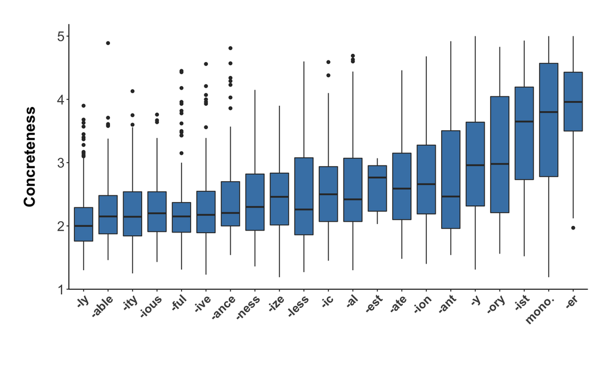

```r
# Plot and aesthetics:

conc_suffix <- conc %>%
  filter(!is.na(SuffixWithMono)) %>%
  filter(IsCompound != 'Compound') %>%
  mutate(SuffixWithMono = ifelse(SuffixWithMono == 'monomorphemic',
                                 'mono.', SuffixWithMono)) %>%
  ggplot(aes(x = reorder(SuffixWithMono, Conc.M), y = Conc.M))

# Geoms:

conc_suffix <- conc_suffix + geom_boxplot(fill = 'steelblue')

# Themes and other properties:

conc_suffix <- conc_suffix +
  labs(x = '', y = 'Concreteness\n') +
  theme_timo +
  theme(legend.position = 'none',
        axis.text.x = element_text(angle = 45, hjust = 1, vjust = 1,
                                   face = 'bold', size = 14))

# Look and save:

conc_suffix
```

```r
ggsave(plot = conc_suffix, filename = '../figures/suffixes.pdf',
       width = 12, height = 4.5)
```

Make a plot of morpheme count:

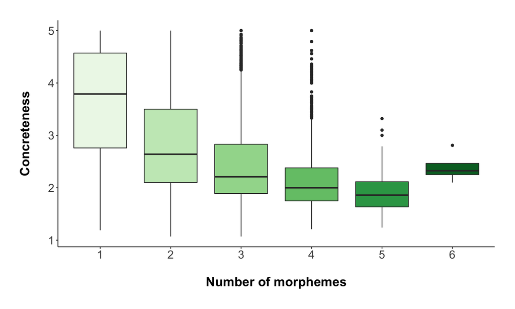

```r
# Plot and aesthetics:

conc_NMorph <- conc %>%
  filter(!is.na(NMorph)) %>%
  filter(IsCompound != 'Compound') %>%
  ggplot(aes(x = factor(NMorph), y = Conc.M,
                    fill = factor(NMorph)))

# Geoms:

conc_NMorph <- conc_NMorph + geom_boxplot()

# Themes and other properties:

conc_NMorph <- conc_NMorph +
  labs(x = '\nNumber of morphemes', y = 'Concreteness\n') +
  scale_fill_brewer(palette = 'Greens') +
  theme_timo +
  theme(legend.position = 'none')

# Look and save:

conc_NMorph
```

```r
ggsave(plot = conc_NMorph, filename = '../figures/morpheme_count.pdf',
       width = 8, height = 4.5)
```

Descriptive values for reporting:

```r
conc %>% group_by(NMorph) %>%
  filter(IsCompound != 'Compound') %>%
  summarize(M = round(mean(Conc.M), 2),
            SD = round(sd(Conc.M), 2),
            N = n()) %>%
  filter(!is.na(NMorph))
```

```
## # A tibble: 6 x 4
##   NMorph     M    SD     N
##    <dbl> <dbl> <dbl> <int>
## 1      1  3.63  1.02  5697
## 2      2  2.84  0.9   5469
## 3      3  2.44  0.76  3602
## 4      4  2.16  0.61  1028
## 5      5  1.93  0.38   135
## 6      6  2.39  0.3      4
```

Make a model of this:

```r
summary(lm(Conc.M ~ NMorph,
           data = filter(conc, IsCompound != 'Compound')))
```

```
##
## Call:
## lm(formula = Conc.M ~ NMorph, data = filter(conc, IsCompound !=
##     "Compound"))
##
## Residuals:
##      Min       1Q   Median       3Q      Max
## -2.32979 -0.70112 -0.08245  0.72888  3.06622
##
## Coefficients:
##              Estimate Std. Error t value Pr(>|t|)
## (Intercept)  4.048454   0.016772  241.38   <2e-16 ***
## NMorph      -0.528669   0.007487  -70.61   <2e-16 ***
## ---
## Signif. codes:  0 '***' 0.001 '**' 0.01 '*' 0.05 '.' 0.1 ' ' 1
##
## Residual standard error: 0.9072 on 15933 degrees of freedom
##   (7062 observations deleted due to missingness)
## Multiple R-squared:  0.2383, Adjusted R-squared:  0.2383
## F-statistic:  4986 on 1 and 15933 DF,  p-value: < 2.2e-16
```

```r
summary(lm(Conc.M ~ NMorph,
           data = filter(conc, IsCompound != 'Compound')))$r.squared
```

```
## [1] 0.2383307
```

Significant effect, explains 24% of the variance. The effect is pretty strong. The coefficient says that for each morpheme, the average concreteness scale is predicted to be lower by half a concreteness point (-0.5). So for two morphemes, you tend to loose a complete concreteness point.

Same for low SD:

Make a model of this:

```r
summary(lm(Conc.M ~ NMorph,
           data = filter(conc_sub, IsCompound != 'Compound')))
```

```
##
## Call:
## lm(formula = Conc.M ~ NMorph, data = filter(conc_sub, IsCompound !=
##     "Compound"))
##
## Residuals:
##     Min      1Q  Median      3Q     Max
## -2.7042 -0.8216  0.1648  0.8484  3.5248
##
## Coefficients:
##             Estimate Std. Error t value Pr(>|t|)
## (Intercept)  4.70054    0.02739  171.60   <2e-16 ***
## NMorph      -0.80633    0.01216  -66.33   <2e-16 ***
## ---
## Signif. codes:  0 '***' 0.001 '**' 0.01 '*' 0.05 '.' 0.1 ' ' 1
##
## Residual standard error: 1.067 on 7445 degrees of freedom
##   (3498 observations deleted due to missingness)
## Multiple R-squared:  0.3714, Adjusted R-squared:  0.3714
## F-statistic:  4400 on 1 and 7445 DF,  p-value: < 2.2e-16
```

```r
summary(lm(Conc.M ~ NMorph,
           data = filter(conc_sub, IsCompound != 'Compound')))$r.squared
```

```
## [1] 0.3714413
```

Here’s an attempt:

```r
xmdl <- lm(Conc.M ~ NMorph + NPhon,
           data = filter(conc, IsCompound != 'Compound'))
summary(xmdl)
```

```
##
## Call:
## lm(formula = Conc.M ~ NMorph + NPhon, data = filter(conc, IsCompound !=
##     "Compound"))
##
## Residuals:
##      Min       1Q   Median       3Q      Max
## -2.55635 -0.68635 -0.07755  0.70407  2.99920
##
## Coefficients:
##              Estimate Std. Error t value Pr(>|t|)
## (Intercept)  4.273105   0.020035  213.28   <2e-16 ***
## NMorph      -0.361449   0.011181  -32.33   <2e-16 ***
## NPhon       -0.082651   0.004145  -19.94   <2e-16 ***
## ---
## Signif. codes:  0 '***' 0.001 '**' 0.01 '*' 0.05 '.' 0.1 ' ' 1
##
## Residual standard error: 0.8961 on 15932 degrees of freedom
##   (7062 observations deleted due to missingness)
## Multiple R-squared:  0.2569, Adjusted R-squared:  0.2568
## F-statistic:  2754 on 2 and 15932 DF,  p-value: < 2.2e-16
```

```r
summary(xmdl)$r.squared
```

```
## [1] 0.2568767
```

```r
# Check variance inflation factors to assess collinearity:

vif(xmdl)
```

```
##   NMorph    NPhon
## 2.285703 2.285703
```

Variance inflation factors indicate no collinearity issues.

Check the number of morphemes now for the low SD subset:

```r
# Pure model:

xmdl <- lm(Conc.M ~ NMorph, conc_sub)
summary(xmdl)
```

```
##
## Call:
## lm(formula = Conc.M ~ NMorph, data = conc_sub)
##
## Residuals:
##     Min      1Q  Median      3Q     Max
## -2.8666 -0.9181  0.1934  0.8634  3.2512
##
## Coefficients:
##             Estimate Std. Error t value Pr(>|t|)
## (Intercept)  4.82592    0.02896  166.64   <2e-16 ***
## NMorph      -0.76928    0.01293  -59.51   <2e-16 ***
## ---
## Signif. codes:  0 '***' 0.001 '**' 0.01 '*' 0.05 '.' 0.1 ' ' 1
##
## Residual standard error: 1.149 on 8703 degrees of freedom
##   (3903 observations deleted due to missingness)
## Multiple R-squared:  0.2892, Adjusted R-squared:  0.2891
## F-statistic:  3541 on 1 and 8703 DF,  p-value: < 2.2e-16
```

```r
summary(xmdl)$r.squared
```

```
## [1] 0.2891927
```

```r
# With word length control:

xmdl <- lm(Conc.M ~ NMorph + NPhon, conc_sub)
summary(xmdl)
```

```
##
## Call:
## lm(formula = Conc.M ~ NMorph + NPhon, data = conc_sub)
##
## Residuals:
##     Min      1Q  Median      3Q     Max
## -3.1944 -0.9015  0.1662  0.8524  3.2559
##
## Coefficients:
##              Estimate Std. Error t value Pr(>|t|)
## (Intercept)  5.149917   0.034867  147.70   <2e-16 ***
## NMorph      -0.524364   0.019791  -26.50   <2e-16 ***
## NPhon       -0.120596   0.007458  -16.17   <2e-16 ***
## ---
## Signif. codes:  0 '***' 0.001 '**' 0.01 '*' 0.05 '.' 0.1 ' ' 1
##
## Residual standard error: 1.132 on 8702 degrees of freedom
##   (3903 observations deleted due to missingness)
## Multiple R-squared:  0.3099, Adjusted R-squared:  0.3098
## F-statistic:  1954 on 2 and 8702 DF,  p-value: < 2.2e-16
```

```r
summary(xmdl)$r.squared
```

```
## [1] 0.3099295
```

Descriptive values for reporting of the low SD set:

```r
conc_sub %>% group_by(NMorph) %>%
  summarize(M = round(mean(Conc.M), 2),
            SD = round(sd(Conc.M), 2),
            N = n()) %>%
  filter(!is.na(NMorph))
```

```
## # A tibble: 6 x 4
##   NMorph     M    SD     N
##    <dbl> <dbl> <dbl> <int>
## 1      1  4.07  1.08  2983
## 2      2  3.33  1.33  3258
## 3      3  2.34  1.03  1796
## 4      4  1.89  0.55   580
## 5      5  1.74  0.23    86
## 6      6  2.2   0.14     2
```

## Linguistic factor 3: Countability:

Needs to be at the lemma level. Let’s make a table of “major_class” by lemma:

```r
BECL_tab <- with(BECL, table(lemma, major_class))
head(BECL_tab) # first six rows
```

```
##               major_class
## lemma          both_mass_count neither_mass_count regular_count regular_mass
##   aa                         0                  1             1            0
##   abbreviation               0                  0             1            0
##   aberrancy                  0                  0             1            0
##   aberration                 0                  0             3            0
##   abnormality                0                  0             1            0
##   abolitionist               0                  0             1            0
```

Let’s get those that are ONLY count or ONLY noun:

```r
colnames(BECL_tab)
```

```
## [1] "both_mass_count"    "neither_mass_count" "regular_count"
## [4] "regular_mass"
```

```r
# Count nouns:

count_only <- BECL_tab[BECL_tab[, 3] >= 1, ]
count_only <- count_only[count_only[, 1] == 0, ]
count_only <- count_only[count_only[, 2] == 0, ]
count_only <- count_only[count_only[, 4] == 0, ]

# Mass nouns:

mass_only <- BECL_tab[BECL_tab[, 4] >= 1, ]
mass_only <- mass_only[mass_only[, 1] == 0, ]
mass_only <- mass_only[mass_only[, 2] == 0, ]
mass_only <- mass_only[mass_only[, 3] == 0, ]

# Extract the actual words:

mass_only <- row.names(mass_only)
count_only <- row.names(count_only)
```

In the “conc” data frame, use these word vectors to label the words accordingly:

```r
conc <- mutate(conc, MassCount = ifelse(Word %in% mass_only, 'mass', NA),
               MassCount = ifelse(Word %in% count_only, 'count', MassCount))

# Low SD set:

conc_sub <- mutate(conc_sub, MassCount = ifelse(Word %in% mass_only, 'mass', NA),
               MassCount = ifelse(Word %in% count_only, 'count', MassCount))
```

Check how many there are:

```r
table(conc$MassCount)
```

```
##
## count  mass
##  3599   801
```

```r
prop.table(table(conc$MassCount))
```

```
##
##     count      mass
## 0.8179545 0.1820455
```

```r
# Low SD set:

table(conc_sub$MassCount)
```

```
##
## count  mass
##  1851   353
```

```r
prop.table(table(conc_sub$MassCount))
```

```
##
##     count      mass
## 0.8398367 0.1601633
```

Make a plot of this:

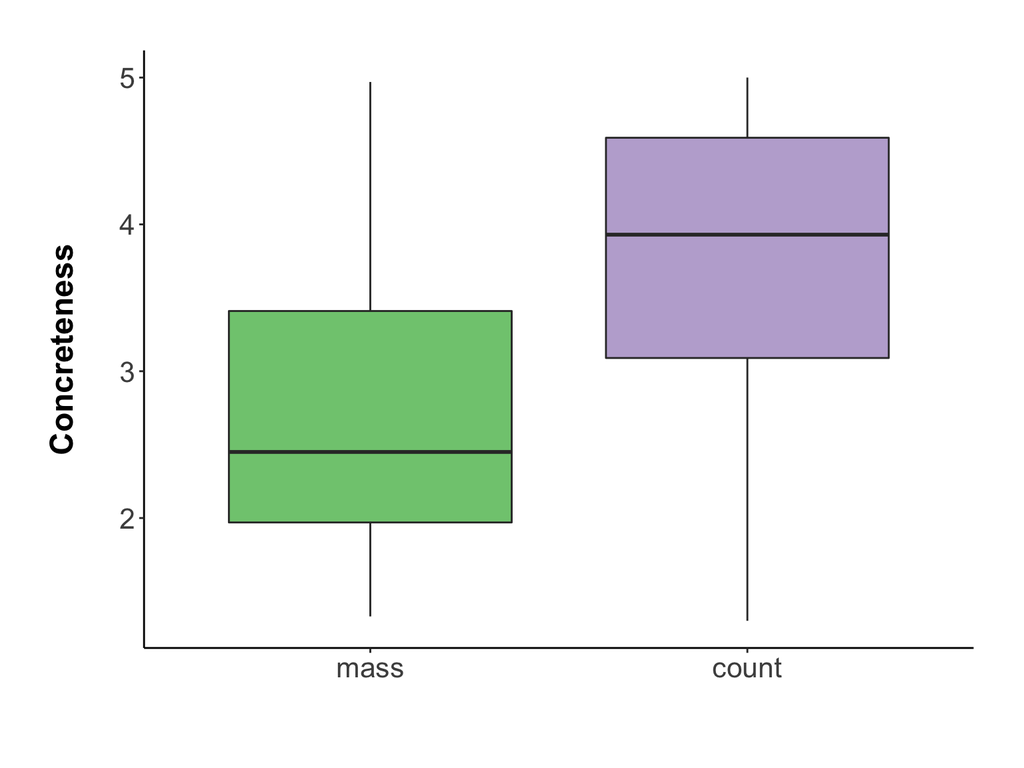

```r
# Plot and aesthetics:

conc_MassCount <- conc %>% filter(!is.na(MassCount)) %>%
  mutate(MassCount = factor(MassCount, levels = c('mass', 'count'))) %>%
  ggplot(aes(x = MassCount, fill = MassCount, y = Conc.M))

# Geoms:

conc_MassCount <- conc_MassCount +
  geom_boxplot()

# Themes and other properties:

conc_MassCount <- conc_MassCount +
  labs(y = 'Concreteness\n', x = '') +
  scale_fill_brewer(palette = 'Accent') +
  theme_timo +
  theme(legend.position = 'none')

# Look and save:

conc_MassCount
```

```r
ggsave(plot = conc_MassCount, filename = '../figures/masscount.pdf',
       width = 6, height = 4.5)
```

Looks like mass is much more abstract. Descriptive values for comparison:

```r
conc %>% group_by(MassCount) %>%
  summarize(M = mean(Conc.M),
            SD = sd(Conc.M),
            N = n()) %>%
  filter(!is.na(MassCount))
```

```
## # A tibble: 2 x 4
##   MassCount     M    SD     N
##   <chr>     <dbl> <dbl> <int>
## 1 count      3.78 0.907  3599
## 2 mass       2.76 0.953   801
```

```r
# Same for low SD:

conc_sub %>% group_by(MassCount) %>%
  summarize(M = mean(Conc.M),
            SD = sd(Conc.M),
            N = n()) %>%
  filter(!is.na(MassCount))
```

```
## # A tibble: 2 x 4
##   MassCount     M    SD     N
##   <chr>     <dbl> <dbl> <int>
## 1 count      4.28 0.860  1851
## 2 mass       2.73 1.25    353
```

Let’s make a model of this:

```r
with(conc, t.test(Conc.M ~ MassCount, var.equal = TRUE))
```

```
##
##  Two Sample t-test
##
## data:  Conc.M by MassCount
## t = 28.736, df = 4398, p-value < 2.2e-16
## alternative hypothesis: true difference in means is not equal to 0
## 95 percent confidence interval:
##  0.9581288 1.0984351
## sample estimates:
## mean in group count  mean in group mass
##            3.784037            2.755755
```

```r
with(conc, cohen.d(Conc.M ~ MassCount, var.equal = TRUE))
```

```
##
## Cohen's d
##
## d estimate: 1.122669 (large)
## 95 percent confidence interval:
##    lower    upper
## 1.042563 1.202775
```

```r
with(conc, summary(lm(Conc.M ~ MassCount, ))$r.squared)
```

```
## [1] 0.1580812
```

```r
# Low SD:

with(conc_sub, t.test(Conc.M ~ MassCount, var.equal = TRUE))
```

```
##
##  Two Sample t-test
##
## data:  Conc.M by MassCount
## t = 28.568, df = 2202, p-value < 2.2e-16
## alternative hypothesis: true difference in means is not equal to 0
## 95 percent confidence interval:
##  1.442928 1.655624
## sample estimates:
## mean in group count  mean in group mass
##            4.280551            2.731275
```

```r
with(conc_sub, cohen.d(Conc.M ~ MassCount, var.equal = TRUE))
```

```
##
## Cohen's d
##
## d estimate: 1.659214 (large)
## 95 percent confidence interval:
##    lower    upper
## 1.535223 1.783205
```

```r
with(conc_sub, summary(lm(Conc.M ~ MassCount))$r.squared)
```

```
## [1] 0.2704159
```

## Factor 4: Etymology

For how many of the words do we have etymological information?

```r
sum(!is.na(conc$Etym))
```

```
## [1] 8783
```

```r
sum(is.na(conc$Etym))
```

```
## [1] 16906
```

Are mass nouns more likely to be French origin?

```r
xtab <- with(conc, table(MassCount, EtymSimplified))
chisq.test(xtab)
```

```
##
##  Pearson's Chi-squared test
##
## data:  xtab
## X-squared = 27.672, df = 2, p-value = 9.796e-07
```

This significance test tests for an uneven distribution of mass/count labels across French/English and other words. We can look at the standardized residuals…

```r
chisq.test(xtab)$stdres
```

```
##          EtymSimplified
## MassCount     French      Latin      Other
##     count -3.9562092 -0.6170642  5.1898365
##     mass   3.9562092  0.6170642 -5.1898365
```

… which show that French words are over-represented for mass nouns, and English words over-represented for count nouns.

What about morphological complexity? First, descriptive stats:

```r
conc %>% group_by(EtymSimplified) %>%
  summarize(M = mean(NMorph, na.rm = TRUE)) %>%
  filter(!is.na(EtymSimplified)) %>%
  arrange(desc(M))
```

```
## # A tibble: 3 x 2
##   EtymSimplified     M
##   <chr>          <dbl>
## 1 Latin           1.95
## 2 French          1.68
## 3 Other           1.22
```

Descriptive stats of concreteness:

```r
conc %>% group_by(EtymSimplified) %>%
  summarize(M = mean(Conc.M, na.rm = TRUE),
            SD = sd(Conc.M, na.rm = TRUE)) %>%
  filter(!is.na(EtymSimplified)) %>%
  arrange(desc(M))
```

```
## # A tibble: 3 x 3
##   EtymSimplified     M    SD
##   <chr>          <dbl> <dbl>
## 1 Other           3.64 1.03
## 2 French          3.11 1.03
## 3 Latin           2.96 0.964
```

Let’s make a Poisson model of this:

```r
nmorph_mdl <- glm(NMorph ~ EtymSimplified,
                  data = conc, family = 'poisson')
summary(nmorph_mdl)
```

```
##
## Call:
## glm(formula = NMorph ~ EtymSimplified, family = "poisson", data = conc)
##
## Deviance Residuals:
##     Min       1Q   Median       3Q      Max
## -0.7501  -0.5659  -0.2039   0.2418   2.0682
##
## Coefficients:
##                     Estimate Std. Error z value Pr(>|z|)
## (Intercept)          0.51717    0.01189  43.479  < 2e-16 ***
## EtymSimplifiedLatin  0.14977    0.02011   7.447 9.52e-14 ***
## EtymSimplifiedOther -0.31993    0.02418 -13.233  < 2e-16 ***
## ---
## Signif. codes:  0 '***' 0.001 '**' 0.01 '*' 0.05 '.' 0.1 ' ' 1
##
## (Dispersion parameter for poisson family taken to be 1)
##
##     Null deviance: 2713.2  on 8018  degrees of freedom
## Residual deviance: 2382.0  on 8016  degrees of freedom
##   (17670 observations deleted due to missingness)
## AIC: 21233
##
## Number of Fisher Scoring iterations: 4
```

```r
anova(nmorph_mdl, test = 'Chisq')
```

```
## Analysis of Deviance Table
##
## Model: poisson, link: log
##
## Response: NMorph
##
## Terms added sequentially (first to last)
##
##
##                Df Deviance Resid. Df Resid. Dev  Pr(>Chi)
## NULL                            8018     2713.2
## EtymSimplified  2   331.19      8016     2382.0 < 2.2e-16 ***
## ---
## Signif. codes:  0 '***' 0.001 '**' 0.01 '*' 0.05 '.' 0.1 ' ' 1
```

Make a model out of this:

```r
etym_mdl <- lm(Conc.M ~ EtymSimplified, data = conc)
summary(etym_mdl)
```

```
##
## Call:
## lm(formula = Conc.M ~ EtymSimplified, data = conc)
##
## Residuals:
##      Min       1Q   Median       3Q      Max
## -2.45343 -0.85561 -0.07561  0.85657  2.04026
##
## Coefficients:
##                     Estimate Std. Error t value Pr(>|t|)
## (Intercept)          3.10561    0.01545 200.957  < 2e-16 ***
## EtymSimplifiedLatin -0.14588    0.02722  -5.359 8.59e-08 ***
## EtymSimplifiedOther  0.53782    0.02792  19.262  < 2e-16 ***
## ---
## Signif. codes:  0 '***' 0.001 '**' 0.01 '*' 0.05 '.' 0.1 ' ' 1
##
## Residual standard error: 1.013 on 8232 degrees of freedom
##   (17454 observations deleted due to missingness)
## Multiple R-squared:  0.05894,    Adjusted R-squared:  0.05871
## F-statistic: 257.8 on 2 and 8232 DF,  p-value: < 2.2e-16
```

```r
etym_sub_mdl <- lm(Conc.M ~ EtymSimplified, data = conc_sub)
summary(etym_sub_mdl)
```

```
##
## Call:
## lm(formula = Conc.M ~ EtymSimplified, data = conc_sub)
##
## Residuals:
##    Min     1Q Median     3Q    Max
## -2.878 -1.294  0.432  1.127  1.936
##
## Coefficients:
##                     Estimate Std. Error t value Pr(>|t|)
## (Intercept)          3.35281    0.02929 114.483  < 2e-16 ***
## EtymSimplifiedLatin -0.28872    0.05285  -5.463 4.99e-08 ***
## EtymSimplifiedOther  0.71521    0.04945  14.465  < 2e-16 ***
## ---
## Signif. codes:  0 '***' 0.001 '**' 0.01 '*' 0.05 '.' 0.1 ' ' 1
##
## Residual standard error: 1.271 on 3730 degrees of freedom
##   (8875 observations deleted due to missingness)
## Multiple R-squared:  0.08039,    Adjusted R-squared:  0.0799
## F-statistic:   163 on 2 and 3730 DF,  p-value: < 2.2e-16
```

Make a graph:

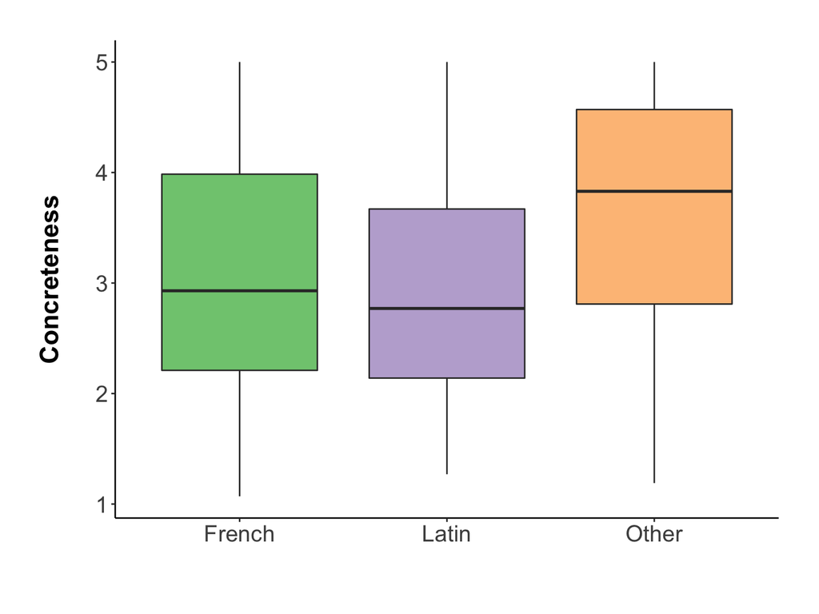

```r
# Plot and aesthetics:

etym_p <- conc %>%
  filter(EtymSize == 'large') %>%
  ggplot(aes(x = EtymSimplified, fill = EtymSimplified, y = Conc.M))

# Geoms:

etym_p <- etym_p +
  geom_boxplot()

# Themes and other properties:

etym_p <- etym_p +
  labs(x = '', y = 'Concreteness\n') +
  scale_fill_brewer(palette = 'Accent') +
  theme_timo +
  theme(legend.position = 'none')


# Look and save:

etym_p
```

```r
ggsave(plot = etym_p, filename = '../figures/etymology.pdf',
       width = 6, height = 4.5)
```

## Simultaneous analysis

Put everything into one regression model, with count and mass nouns treated as separate words:

```r
conc$SUBTL_POS2 <- conc$SUBTL_POS
conc[which(conc$MassCount == 'mass'), ]$SUBTL_POS2 <- 'mass noun'
conc[which(conc$MassCount == 'count'), ]$SUBTL_POS2 <- 'count noun'
conc_red <- filter(conc,
                   SUBTL_POS2 != 'Noun')
```

Do the same thing for the low-SD set:

```r
conc_sub$SUBTL_POS2 <- conc_sub$SUBTL_POS
conc_sub[which(conc_sub$MassCount == 'mass'), ]$SUBTL_POS2 <- 'mass noun'
conc_sub[which(conc_sub$MassCount == 'count'), ]$SUBTL_POS2 <- 'count noun'
conc_sub_red <- filter(conc_sub,
                       SUBTL_POS2 != 'Noun')
```

Run a model:

```r
full_mdl <- lm(Conc.M ~ SUBTL_POS2 + NMorph + EtymSimplified,
               data = filter(conc_red, IsCompound != 'Compound'))
summary(full_mdl)$r.squared # full model
```

```
## [1] 0.3950631
```

```r
anova(full_mdl)# significant effects of everything
```

```
## Analysis of Variance Table
##
## Response: Conc.M
##                  Df Sum Sq Mean Sq F value    Pr(>F)
## SUBTL_POS2        5 1723.8  344.76  560.71 < 2.2e-16 ***
## NMorph            1  274.6  274.62  446.64 < 2.2e-16 ***
## EtymSimplified    2  129.4   64.68  105.19 < 2.2e-16 ***
## Residuals      5299 3258.1    0.61
## ---
## Signif. codes:  0 '***' 0.001 '**' 0.01 '*' 0.05 '.' 0.1 ' ' 1
```

Get the unique contributions against the full model:

```r
mdl_no_SUBTL <- lm(Conc.M ~ NMorph + EtymSimplified,
               data = filter(conc_red, IsCompound != 'Compound'))
mdl_no_morph <- lm(Conc.M ~ SUBTL_POS2 + EtymSimplified,
               data = filter(conc_red, IsCompound != 'Compound'))
mdl_no_etym <- lm(Conc.M ~ SUBTL_POS2 + NMorph,
               data = filter(conc_red, IsCompound != 'Compound'))

# r-squareds:

rsq_all <- summary(full_mdl)$r.squared
rsq_all - summary(mdl_no_SUBTL)$r.squared
```

```
## [1] 0.2578512
```

```r
rsq_all - summary(mdl_no_morph)$r.squared
```

```
## [1] 0.03340205
```

```r
rsq_all - summary(mdl_no_etym)$r.squared
```

```
## [1] -0.03425168
```

Partial r-squared:

```r
rsq.partial(full_mdl)
```

```
## $adjustment
## [1] FALSE
##
## $variable
## [1] "SUBTL_POS2"     "NMorph"         "EtymSimplified"
##
## $partial.rsq
## [1]  0.29885806  0.05232650 -0.06001851
```

Similar picture.

Run a model on the low-SD data::

```r
sub_mdl <- lm(Conc.M ~ SUBTL_POS2 + NMorph + EtymSimplified,
              data = filter(conc_sub_red, IsCompound != 'Compound'))
summary(sub_mdl)$r.squared # full model
```

```
## [1] 0.5870731
```

```r
anova(sub_mdl)# significant effects of everything
```

```
## Analysis of Variance Table
##
## Response: Conc.M
##                  Df  Sum Sq Mean Sq F value    Pr(>F)
## SUBTL_POS2        5 2077.81  415.56 568.842 < 2.2e-16 ***
## NMorph            1  231.10  231.10 316.343 < 2.2e-16 ***
## EtymSimplified    2   72.68   36.34  49.744 < 2.2e-16 ***
## Residuals      2293 1675.13    0.73
## ---
## Signif. codes:  0 '***' 0.001 '**' 0.01 '*' 0.05 '.' 0.1 ' ' 1
```

Low-SD partial R-squareds:

```r
rsq.partial(sub_mdl)
```

```
## $adjustment
## [1] FALSE
##
## $variable
## [1] "SUBTL_POS2"     "NMorph"         "EtymSimplified"
##
## $partial.rsq
## [1]  0.45660469  0.08668684 -0.10074274
```

Check variance inflation factors:

```r
vif(full_mdl)
```

```
##                    GVIF Df GVIF^(1/(2*Df))
## SUBTL_POS2     1.213185  5        1.019513
## NMorph         1.245853  1        1.116178
## EtymSimplified 1.238729  2        1.054980
```

Absolutely no collinearity worthy of mentioning.

Do the same thing for the low SD words:

```r
conc_red <- filter(conc_sub, SUBTL_POS %in% POS)
full_mdl_sub <- lm(Conc.M ~ NMorph + SUBTL_POS + EtymSimplified,
                   data = conc_red)
anova(full_mdl_sub)# significant effects of everything
```

```
## Analysis of Variance Table
##
## Response: Conc.M
##                  Df  Sum Sq Mean Sq  F value    Pr(>F)
## NMorph            1 1554.40 1554.40 1748.980 < 2.2e-16 ***
## SUBTL_POS         4 1365.01  341.25  383.970 < 2.2e-16 ***
## EtymSimplified    2  158.73   79.36   89.299 < 2.2e-16 ***
## Residuals      3557 3161.27    0.89
## ---
## Signif. codes:  0 '***' 0.001 '**' 0.01 '*' 0.05 '.' 0.1 ' ' 1
```

```r
summary(full_mdl_sub)
```

```
##
## Call:
## lm(formula = Conc.M ~ NMorph + SUBTL_POS + EtymSimplified, data = conc_red)
##
## Residuals:
##     Min      1Q  Median      3Q     Max
## -3.2386 -0.5612  0.2097  0.6343  3.1297
##
## Coefficients:
##                     Estimate Std. Error t value Pr(>|t|)
## (Intercept)          3.30089    0.06280  52.562  < 2e-16 ***
## NMorph              -0.64354    0.02341 -27.492  < 2e-16 ***
## SUBTL_POSAdverb     -0.93310    0.15129  -6.168 7.70e-10 ***
## SUBTL_POSFunction   -0.99726    0.17820  -5.596 2.36e-08 ***
## SUBTL_POSNoun        1.42838    0.04498  31.757  < 2e-16 ***
## SUBTL_POSVerb        0.39727    0.05950   6.677 2.83e-11 ***
## EtymSimplifiedLatin  0.10740    0.04120   2.607  0.00917 **
## EtymSimplifiedOther  0.52292    0.03924  13.325  < 2e-16 ***
## ---
## Signif. codes:  0 '***' 0.001 '**' 0.01 '*' 0.05 '.' 0.1 ' ' 1
##
## Residual standard error: 0.9427 on 3557 degrees of freedom
##   (5550 observations deleted due to missingness)
## Multiple R-squared:  0.4933, Adjusted R-squared:  0.4923
## F-statistic: 494.8 on 7 and 3557 DF,  p-value: < 2.2e-16
```

## Subset analysis for high-and low concreteness words:

Check whether linguistic factors explain results better for high or low abstractness words:

```r
conc_red_highC <- filter(conc_red, Conc.M > median(Conc.M))
conc_red_lowC <- filter(conc_red, Conc.M < median(Conc.M))
```

The corresponding models:

```r
full_highC <- lm(Conc.M ~ SUBTL_POS + NMorph + EtymSimplified,
                 data = conc_red_highC)
full_lowC <- lm(Conc.M ~ SUBTL_POS + NMorph + EtymSimplified,
                data = conc_red_lowC)
anova(full_highC)
```

```
## Analysis of Variance Table
##
## Response: Conc.M
##                  Df  Sum Sq Mean Sq F value    Pr(>F)
## SUBTL_POS         4   7.527  1.8817  30.763 < 2.2e-16 ***
## NMorph            1   5.673  5.6726  92.741 < 2.2e-16 ***
## EtymSimplified    2   1.435  0.7173  11.727 8.679e-06 ***
## Residuals      1894 115.849  0.0612
## ---
## Signif. codes:  0 '***' 0.001 '**' 0.01 '*' 0.05 '.' 0.1 ' ' 1
```

```r
anova(full_lowC)
```

```
## Analysis of Variance Table
##
## Response: Conc.M
##                  Df Sum Sq Mean Sq F value    Pr(>F)
## SUBTL_POS         4  56.98 14.2452  37.246 < 2.2e-16 ***
## NMorph            1  24.19 24.1898  63.247 3.388e-15 ***
## EtymSimplified    2  27.15 13.5746  35.492 8.191e-16 ***
## Residuals      1623 620.74  0.3825
## ---
## Signif. codes:  0 '***' 0.001 '**' 0.01 '*' 0.05 '.' 0.1 ' ' 1
```

```r
summary(full_highC)$r.squared
```

```
## [1] 0.1121517
```

```r
summary(full_lowC)$r.squared
```

```
## [1] 0.1485748
```

## Calculate unique R-squared for all things:

Loop through predictors and drop them to look at how much variance they contribute. First, create tibbles where there’s no missingness:

```r
nomiss <- filter(conc,
                 !is.na(SUBTL_POS),
                 !is.na(NMorph),
                 !is.na(EtymSimplified))
nomiss_sub <- filter(conc_sub,
                     !is.na(SUBTL_POS),
                     !is.na(NMorph),
                     !is.na(EtymSimplified))
```

Create a vector with all the predictors:

```r
preds <- c('SUBTL_POS', 'NMorph', 'EtymSimplified')
```

Create tables to append the different R-squared values to:

```r
rsq <- tibble(preds, RSQ = NA, RSQ_sub = NA) %>%
  mutate(RSQ = as.numeric(RSQ),
         RSQ_sub = as.numeric(RSQ_sub))
```

Then, loop through all the models and drop one of the terms:

```r
for (i in seq_along(preds)) {
  myFormula <- str_c(preds[-i], collapse = ' + ')
  myFormula <- str_c('Conc.M ~ ', myFormula)
  rsq[i, ]$RSQ <- glance(lm(myFormula, data = nomiss))$r.squared
  rsq[i, ]$RSQ_sub <- glance(lm(myFormula, data = nomiss_sub))$r.squared
}
```

Calculate the R-squared differences:

```r
rsq <- mutate(rsq,
              RSQ_diff = glance(full_mdl)$r.squared - RSQ,
              RSQ_sub_diff = glance(full_mdl_sub)$r.squared - RSQ_sub)
rsq
```

```
## # A tibble: 3 x 5
##   preds            RSQ RSQ_sub RSQ_diff RSQ_sub_diff
##   <chr>          <dbl>   <dbl>    <dbl>        <dbl>
## 1 SUBTL_POS      0.160   0.266   0.235        0.227
## 2 NMorph         0.255   0.386   0.140        0.108
## 3 EtymSimplified 0.309   0.468   0.0859       0.0254
```

Visualization of the R-squared values:

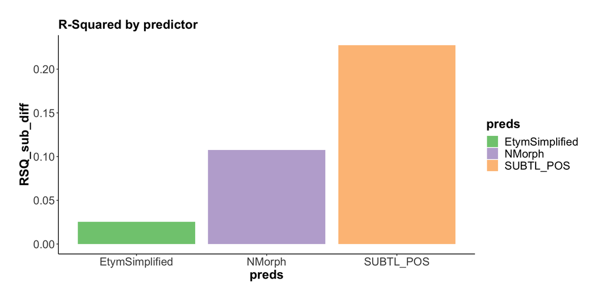

```r
rsq %>%
  ggplot(aes(x = preds, y = RSQ_sub_diff, fill = preds)) +
  geom_bar(stat = 'identity') +
  theme_timo +
  scale_fill_brewer(palette = 'Accent') +
  ggtitle('R-Squared by predictor')
```

```r
ggsave('../figures/r_squared.pdf', width = 8, height = 4.5)
```

## Do this analysis for nouns only:

```r
nouns <- filter(conc, SUBTL_POS == 'Noun')
noun_mdl <- lm(Conc.M ~ NMorph + MassCount + EtymSimplified, data = nouns)
anova(noun_mdl)
```

```
## Analysis of Variance Table
##
## Response: Conc.M
##                  Df  Sum Sq Mean Sq F value    Pr(>F)
## NMorph            1  350.77  350.77 462.285 < 2.2e-16 ***
## MassCount         1  193.82  193.82 255.440 < 2.2e-16 ***
## EtymSimplified    2   50.38   25.19  33.201 6.151e-15 ***
## Residuals      2259 1714.08    0.76
## ---
## Signif. codes:  0 '***' 0.001 '**' 0.01 '*' 0.05 '.' 0.1 ' ' 1
```

```r
summary(noun_mdl)
```

```
##
## Call:
## lm(formula = Conc.M ~ NMorph + MassCount + EtymSimplified, data = nouns)
##
## Residuals:
##     Min      1Q  Median      3Q     Max
## -2.4567 -0.6546  0.1226  0.7006  2.2354
##
## Coefficients:
##                     Estimate Std. Error t value Pr(>|t|)
## (Intercept)          4.17145    0.04716  88.457  < 2e-16 ***
## NMorph              -0.35205    0.02639 -13.340  < 2e-16 ***
## MassCountmass       -0.77271    0.04957 -15.588  < 2e-16 ***
## EtymSimplifiedLatin  0.06012    0.04753   1.265    0.206
## EtymSimplifiedOther  0.38734    0.04767   8.125  7.3e-16 ***
## ---
## Signif. codes:  0 '***' 0.001 '**' 0.01 '*' 0.05 '.' 0.1 ' ' 1
##
## Residual standard error: 0.8711 on 2259 degrees of freedom
##   (8591 observations deleted due to missingness)
## Multiple R-squared:  0.2577, Adjusted R-squared:  0.2564
## F-statistic:   196 on 4 and 2259 DF,  p-value: < 2.2e-16
```

Same for reduced data frame:

```r
noun_sub <- filter(conc_sub, SUBTL_POS == 'Noun')
noun_sub_mdl <- lm(Conc.M ~ NMorph + MassCount + EtymSimplified,
                   data = noun_sub)
anova(noun_sub_mdl)
```

```
## Analysis of Variance Table
##
## Response: Conc.M
##                  Df Sum Sq Mean Sq F value    Pr(>F)
## NMorph            1 361.40  361.40 494.385 < 2.2e-16 ***
## MassCount         1 214.33  214.33 293.201 < 2.2e-16 ***
## EtymSimplified    2  15.88    7.94  10.864  2.12e-05 ***
## Residuals      1144 836.26    0.73
## ---
## Signif. codes:  0 '***' 0.001 '**' 0.01 '*' 0.05 '.' 0.1 ' ' 1
```

```r
summary(noun_sub_mdl)
```

```
##
## Call:
## lm(formula = Conc.M ~ NMorph + MassCount + EtymSimplified, data = noun_sub)
##
## Residuals:
##     Min      1Q  Median      3Q     Max
## -2.8839 -0.2439  0.1761  0.4405  2.4806
##
## Coefficients:
##                     Estimate Std. Error t value Pr(>|t|)
## (Intercept)          4.92030    0.06675  73.710  < 2e-16 ***
## NMorph              -0.57081    0.04035 -14.147  < 2e-16 ***
## MassCountmass       -1.23851    0.07415 -16.702  < 2e-16 ***
## EtymSimplifiedLatin  0.09765    0.06890   1.417    0.157
## EtymSimplifiedOther  0.28440    0.06108   4.656  3.6e-06 ***
## ---
## Signif. codes:  0 '***' 0.001 '**' 0.01 '*' 0.05 '.' 0.1 ' ' 1
##
## Residual standard error: 0.855 on 1144 degrees of freedom
##   (4502 observations deleted due to missingness)
## Multiple R-squared:  0.4143, Adjusted R-squared:  0.4123
## F-statistic: 202.3 on 4 and 1144 DF,  p-value: < 2.2e-16
```

Get data frames:

```r
nomiss_noun <- filter(conc,
                 SUBTL_POS == 'Noun',
                 !is.na(NMorph),
                 !is.na(MassCount),
                 !is.na(EtymSimplified))
nomiss_noun_sub <- filter(conc_sub,
                 SUBTL_POS == 'Noun',
                 !is.na(NMorph),
                 !is.na(MassCount),
                 !is.na(EtymSimplified))
```

Create a vector with all the predictors:

```r
preds <- c('MassCount', 'NMorph', 'EtymSimplified')
```

Create tables to append the different R-squared values to:

```r
rsq_nouns <- tibble(preds, RSQ = NA, RSQ_sub = NA) %>%
  mutate(RSQ = as.numeric(RSQ),
         RSQ_sub = as.numeric(RSQ_sub))
```

Then, loop through all the models and drop one of the terms:

```r
for (i in seq_along(preds)) {
  myFormula <- str_c(preds[-i], collapse = ' + ')
  myFormula <- str_c('Conc.M ~ ', myFormula)
  rsq_nouns[i, ]$RSQ <- glance(lm(myFormula, data = nomiss_noun))$r.squared
  rsq_nouns[i, ]$RSQ_sub <- glance(lm(myFormula, data = nomiss_noun_sub))$r.squared
}
```

Calculate the R-squared differences:

```r
rsq_nouns <- mutate(rsq_nouns,
              RSQ_diff = glance(noun_mdl)$r.squared - RSQ,
              RSQ_sub_diff = glance(noun_sub_mdl)$r.squared - RSQ_sub)
rsq_nouns
```

```
## # A tibble: 3 x 5
##   preds            RSQ RSQ_sub RSQ_diff RSQ_sub_diff
##   <chr>          <dbl>   <dbl>    <dbl>        <dbl>
## 1 MassCount      0.178   0.272   0.0798       0.143
## 2 NMorph         0.199   0.312   0.0585       0.102
## 3 EtymSimplified 0.236   0.403   0.0218       0.0111
```

Visualization of the R-squared values:

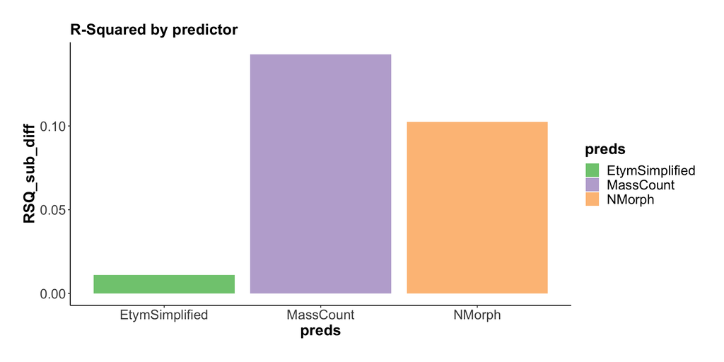

```r
rsq_nouns %>%
  ggplot(aes(x = preds, y = RSQ_sub_diff, fill = preds)) +
  geom_bar(stat = 'identity') +
  theme_timo +
  scale_fill_brewer(palette = 'Accent') +
  ggtitle('R-Squared by predictor')
```

## Are adverbs more concrete?

The adverb result is a bit unexpected. Why could this be?

```r
conc$LogFreq <- log10(ELP[match(conc$Lemmas, ELP$Word), ]$Freq_N + 1)
```

Check:

```r
conc %>% group_by(SUBTL_POS) %>%
  summarize(LogFreq = mean(LogFreq, na.rm = TRUE))
```

```
## # A tibble: 6 x 2
##   SUBTL_POS LogFreq
##   <chr>       <dbl>
## 1 Adjective   0.769
## 2 Adverb      0.786
## 3 Function    0.928
## 4 Noun        0.838
## 5 Verb        0.863
## 6 <NA>        0.719
```

This completes this analysis.